Kornpob Bhirombhakdi

kbhirombhakdi@stsci.edu

# Story

The diagonal curved-line structure of G102, as its detector defect, causes some issues during the reduction pipeline. A section of the line (approximately linear) can be located at about pixel (650,540) to (710,562). The flatfield image should mitigate the impact from this structure.

However, in our reduction pipeline in which we i) estimate a smooth background by using 2D polynomial, ii) subtract the background, and iii) perform flatfielding, we found that the performing flatfielding after background subtraction tends to cause issues. For example, negative pixels from background subtraction would even be more negative after flatfielding in those pixels lie along the structure. Therefore, we should implement a different pipeline flow such as performing flatfielding before background subtraction.

Historically, it was the flow in aXe that flatfielding would be perform after background subtraction. From our understanding, since aXe performs global background subtraction and the flatfield is source dependent, performing flatfielding after the global background subtraction is required. However, for our flow, we focus on a single source extraction. Therefore, performing flatfielding before background subtraction should be viable.

Reports about how the flatfield image was constructed can be found in ISRs:

- WFC3-2008-15 (TV2)
- WFC3-2008-16 (TV3)
- WFC3-2011-05 (Revised; adding large-scale variation)

# Task

- Show how much the difference between performing flatfielding after (i.e., old flow) and before (i.e., new flow) would be.

# Test set

We will use a test set produced from hstgrism. idlk01jmq is G102 of GRB 190829A. Mainly, we can use rootname_extract.fits from both folders.

- rootname_noReplacement_G102_201909: This folder was produced by using the original idlk01jmq_flt.fits in hstgrism. Since the object has another contaminating object nearby that we can see from the 2D cutout around the top-right corner, its estimated 2D polynomial background is not quite satisfied. Therefore, we produced another folder.
- rootname_G102_201909: This folder tried to fix the background estimation problem caused by the contaminating object. First, we estimated a 2D polynomial background around the contaminating object, and replaced that region with the estimated background only. Then, we continued with the extraction of the GRB. We can see that this estimated background around the GRB (BKG2) is better than the one before removing the object (BKG1) in the other folder.

In order to address the issue here (about pipeline flow), we would use

- Extraction region from noReplacement folder in _extract.fits
- BKG2
- Flatfield from any folder

```python
from astropy.io import fits
import numpy as np
import matplotlib.pyplot as plt
import os,glob,copy
cwd = os.getcwd()
cwd
```

```
'/Users/kbhirombhakdi/_work/GRB190829A/15_try_flat_before_bkg'
```

```python
obj = fits.open('/Users/kbhirombhakdi/_work/GRB190829A/15_try_flat_before_bkg/test_set/idlk01jmq_noReplacement_G102_201909/idlk01jmq_extract.fits')[1].data
bkg = fits.open('/Users/kbhirombhakdi/_work/GRB190829A/15_try_flat_before_bkg/test_set/idlk01jmq_G102_201909/idlk01jmq_extract.fits')[2].data
flat = fits.open('/Users/kbhirombhakdi/_work/GRB190829A/15_try_flat_before_bkg/test_set/idlk01jmq_G102_201909/idlk01jmq_extract.fits')[3].data
```

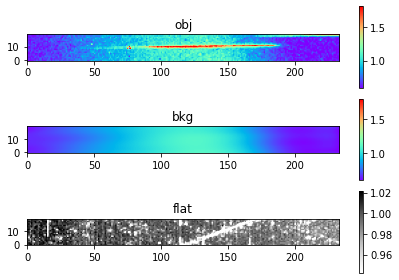

```python
fig = plt.figure()
ax = fig.add_subplot(3,1,1)
m = np.isfinite(obj)
vmin,vmax = np.percentile(obj[m],5.),np.percentile(obj[m],99.)
im = ax.imshow(obj,origin='lower',cmap='rainbow',vmin=vmin,vmax=vmax)
fig.colorbar(im)
ax.set_title('obj',fontsize=12)
ax = fig.add_subplot(3,1,2)
im = ax.imshow(bkg,origin='lower',cmap='rainbow',vmin=vmin,vmax=vmax)
fig.colorbar(im)
ax.set_title('bkg',fontsize=12)
ax = fig.add_subplot(3,1,3)
m = np.isfinite(flat)
vmin,vmax = np.percentile(flat[m],5.),np.percentile(flat[m],99.)
im = ax.imshow(flat,origin='lower',cmap='Greys',vmin=vmin,vmax=vmax)
fig.colorbar(im)
ax.set_title('flat',fontsize=12)
fig.tight_layout()
fig.savefig('overview.pdf',saveformat='pdf',bbox_inches='tight')
```

```python
case1 = (obj - bkg)/flat
case2 = (obj/flat)-bkg
```

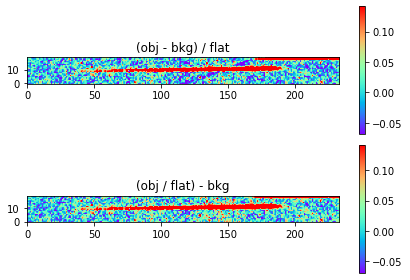

```python
fig = plt.figure()
m = np.isfinite(case1)
vmin,vmax = np.percentile(case1[m],10.),np.percentile(case1[m],90.)
ax = fig.add_subplot(2,1,1)
im = ax.imshow(case1,origin='lower',cmap='rainbow',vmin=vmin,vmax=vmax)
fig.colorbar(im)
ax.set_title('(obj - bkg) / flat', fontsize=12)
ax = fig.add_subplot(2,1,2)
im = ax.imshow(case2,origin='lower',cmap='rainbow',vmin=vmin,vmax=vmax)
fig.colorbar(im)
ax.set_title('(obj / flat) - bkg',fontsize=12)
fig.tight_layout()
fig.savefig('compare.pdf',saveformat='pdf',bbox_inches='tight')
```

# Conclusion

We can see that the new flow (i.e., performing flatfielding before) removes the structure.